# Exploring the U.S. National Oceanic and Atmospheric Administion’s (NOAA) storm database

Ely Xavier

February 17, 2018

## Introduction

Storms and other severe weather events can cause both public health and economic problems for communities and municipalities. Many severe events can result in fatalities, injuries, and property damage, and preventing such outcomes to the extent possible is a key concern.

This project involves exploring the U.S. National Oceanic and Atmospheric Administration’s (NOAA) storm database. This database tracks characteristics of major storms and weather events in the United States, including when and where they occur, as well as estimates of any fatalities, injuries, and property damage.

## Downloading and loading the dataset and libraries

### Load the required libraries

```r
library(ggplot2)
library(gridExtra)
library(dplyr)
library(R.utils)
```

### Downloading and reading data

Use cache=TRUE when starting this code block

```r
url <- "https://d396qusza40orc.cloudfront.net/repdata%2Fdata%2FStormData.csv.bz2"
download.file(url, "StormData.csv.bz2")

if (!exists("StormData.csv")) {
    # Extract file if not already extracted
    if (file.exists("StormData.csv.bz2")) {
        if (!file.exists("StormData.csv")) {
            bunzip2("StormData.csv.bz2", "StormData.csv", overwrite = F)
        }

}
    }
```

```r
StormData <- read.csv("StormData.csv", sep = ",")
```

### Summary of the dataset

```r
head(StormData)
```

```
##   STATE__           BGN_DATE BGN_TIME TIME_ZONE COUNTY COUNTYNAME STATE
## 1       1  4/18/1950 0:00:00     0130       CST     97     MOBILE    AL
## 2       1  4/18/1950 0:00:00     0145       CST      3    BALDWIN    AL
## 3       1  2/20/1951 0:00:00     1600       CST     57    FAYETTE    AL
## 4       1   6/8/1951 0:00:00     0900       CST     89    MADISON    AL
## 5       1 11/15/1951 0:00:00     1500       CST     43    CULLMAN    AL
## 6       1 11/15/1951 0:00:00     2000       CST     77 LAUDERDALE    AL
##    EVTYPE BGN_RANGE BGN_AZI BGN_LOCATI END_DATE END_TIME COUNTY_END
## 1 TORNADO         0                                               0
## 2 TORNADO         0                                               0
## 3 TORNADO         0                                               0
## 4 TORNADO         0                                               0
## 5 TORNADO         0                                               0
## 6 TORNADO         0                                               0
##   COUNTYENDN END_RANGE END_AZI END_LOCATI LENGTH WIDTH F MAG FATALITIES
```

[output cut: 20 more lines]

## Data Processing

### Public Health (fatalities and injuries)

Health impact, total fatalities and the total injuries for each event type (EVTYPE), are calculated below. The code blocks for these calculations are shown as follow.

```r
StormData.fatalities <- StormData %>% select(EVTYPE, FATALITIES) %>% group_by(EVTYPE) %>% summarise(total.fatalities = sum(FATALITIES)) %>% arrange(-total.fatalities)
head(StormData.fatalities)
```

```
## # A tibble: 6 x 2
##   EVTYPE         total.fatalities
##   <fct>                     <dbl>
## 1 TORNADO                    5633
## 2 EXCESSIVE HEAT             1903
## 3 FLASH FLOOD                 978
## 4 HEAT                        937
## 5 LIGHTNING                   816
## 6 TSTM WIND                   504
```

```r
StormData.injuries <- StormData %>% select(EVTYPE, INJURIES) %>% group_by(EVTYPE) %>% summarise(total.injuries = sum(INJURIES)) %>% arrange(-total.injuries)
head(StormData.injuries)
```

```
## # A tibble: 6 x 2
##   EVTYPE         total.injuries
##   <fct>                   <dbl>
## 1 TORNADO                 91346
## 2 TSTM WIND                6957
## 3 FLOOD                    6789
## 4 EXCESSIVE HEAT           6525
## 5 LIGHTNING                5230
## 6 HEAT                     2100
```

### Economic Impact

The data provides two types of economic impact; property damage (PROPDMG) and crop damage (CROPDMG). The actual damage is in $USD, indicated by PROPDMGEXP and CROPDMGEXP parameters. According to this [link](https://rstudio-pubs-static.s3.amazonaws.com/58957_37b6723ee52b455990e149edde45e5b6.html), the index in the PROPDMGEXP and CROPDMGEXP can be interpreted as the following:

- H,h,K,k,M,m,B,b,+,-,?,0,1,2,3,4,5,6,7,8, and blank-character
- H,h = hundreds = 100
- K,k = kilos = thousands = 1,000
- M,m = millions = 1,000,000
- B,b = billions = 1,000,000,000
- (+) = 1
- (-) = 0
- (?) = 0
- black/empty character = 0
- numeric 0..8 = 10

The total damage caused by each event type is calculated by the following code.

```r
StormData.damage <- StormData %>% select(EVTYPE, PROPDMG,PROPDMGEXP,CROPDMG,CROPDMGEXP)

Symbol <- sort(unique(as.character(StormData.damage$PROPDMGEXP)))
Multiplier <- c(0,0,0,1,10,10,10,10,10,10,10,10,10,10^9,10^2,10^2,10^3,10^6,10^6)
convert.Multiplier <- data.frame(Symbol, Multiplier)

StormData.damage$Prop.Multiplier <- convert.Multiplier$Multiplier[match(StormData.damage$PROPDMGEXP, convert.Multiplier$Symbol)]
StormData.damage$Crop.Multiplier <- convert.Multiplier$Multiplier[match(StormData.damage$CROPDMGEXP, convert.Multiplier$Symbol)]

StormData.damage <- StormData.damage %>% mutate(PROPDMG = PROPDMG*Prop.Multiplier) %>% mutate(CROPDMG = CROPDMG*Crop.Multiplier) %>% mutate(TOTAL.DMG = PROPDMG+CROPDMG)

StormData.damage.total <- StormData.damage %>% group_by(EVTYPE) %>% summarize(TOTAL.DMG.EVTYPE = sum(TOTAL.DMG))%>% arrange(-TOTAL.DMG.EVTYPE)

head(StormData.damage.total)
```

```
## # A tibble: 6 x 2
##   EVTYPE            TOTAL.DMG.EVTYPE
##   <fct>                        <dbl>
## 1 FLOOD                 150319678250
## 2 HURRICANE/TYPHOON      71913712800
## 3 TORNADO                57352117607
## 4 STORM SURGE            43323541000
## 5 FLASH FLOOD            17562132111
## 6 DROUGHT                15018672000
```

## Results

### Health Impact

The following code block and plot shows the top ten events with the highest total fatalities and injuries.

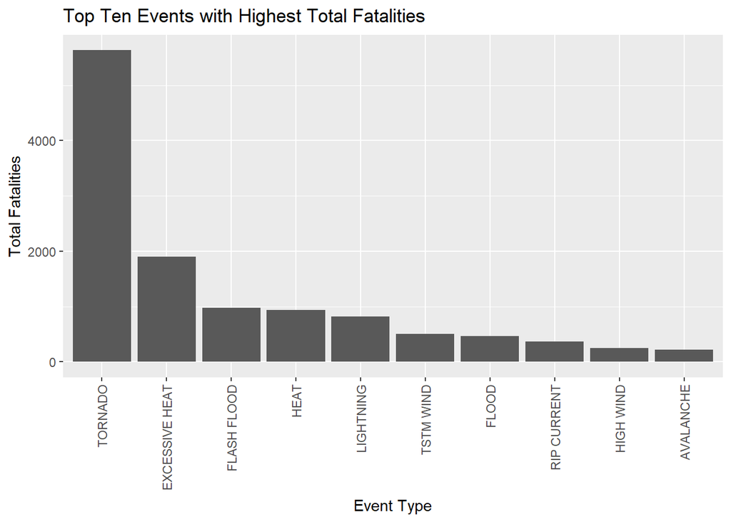

```r
fatal.plot <- ggplot(StormData.fatalities[1:10,], aes(x=reorder(EVTYPE, -total.fatalities), y=total.fatalities))+geom_bar(stat="identity") + theme(axis.text.x = element_text(angle=90, vjust=0.5, hjust=1))+ggtitle("Top Ten Events with Highest Total Fatalities") +labs(x="Event Type", y="Total Fatalities")
fatal.plot
```

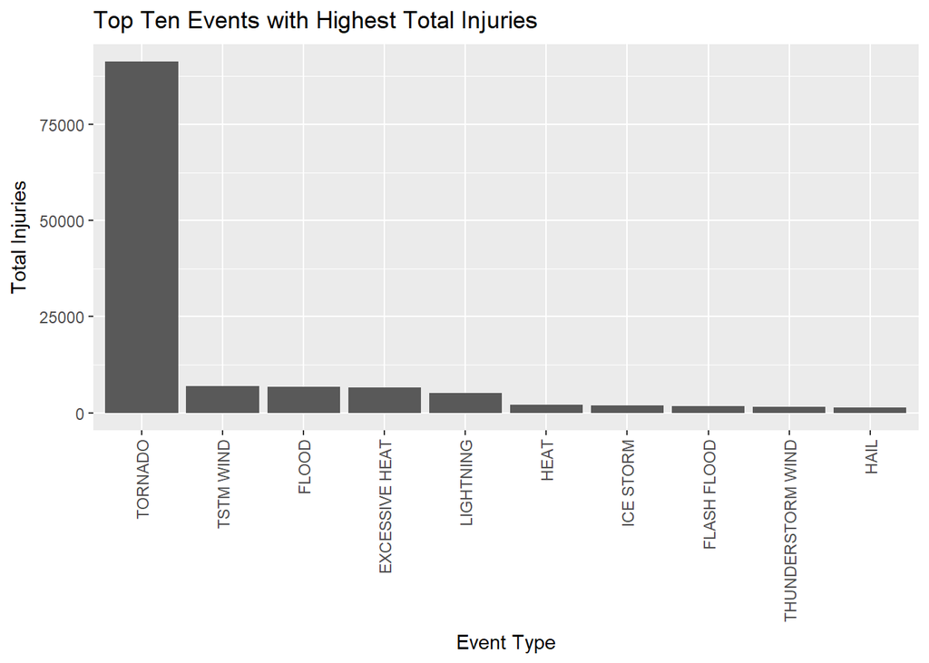

```r
injury.plot <- ggplot(StormData.injuries[1:10,], aes(x=reorder(EVTYPE, -total.injuries), y=total.injuries))+geom_bar(stat="identity") + theme(axis.text.x = element_text(angle=90, vjust=0.5, hjust=1))+ggtitle("Top Ten Events with Highest Total Injuries") +labs(x="Event Type", y="Total Injuries")
injury.plot
```

As shown in the previous two plots, tornados cause the highest rate of fatalities and injuries.

### Economic Impact

The following code block and plot shows the top ten events with the highest economic impact.

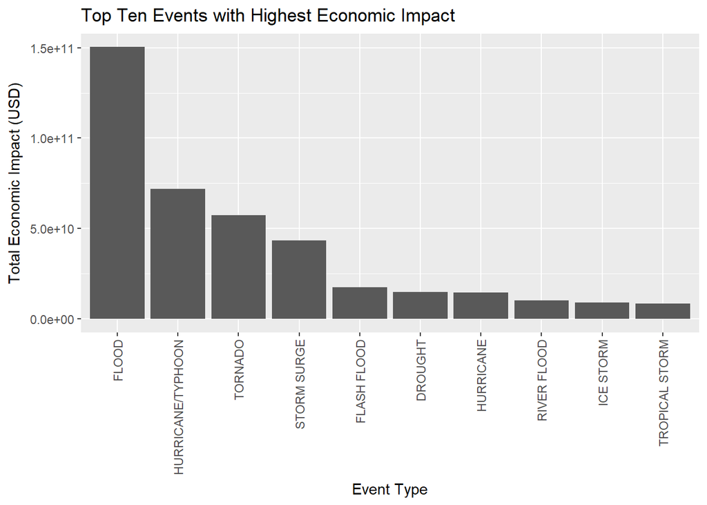

```r
economic.plot <- ggplot(StormData.damage.total[1:10,], aes(x=reorder(EVTYPE, -TOTAL.DMG.EVTYPE), y=TOTAL.DMG.EVTYPE))+geom_bar(stat="identity") + theme(axis.text.x = element_text(angle=90, vjust=0.5, hjust=1))+ggtitle("Top Ten Events with Highest Economic Impact") +labs(x="Event Type", y="Total Economic Impact (USD)")
economic.plot
```

As shown in the previous plot, floods cause the highest economic impact, at almost 150 billion USD for the data and timeframe analyzed. The second highest economic impact is caused by hurricanes/typhoons, at about 70 billion USD.